# Preoperative Atelectasis

Part 1: Overview, selection criteria, and missing data

Author

Javier Mancilla Galindo

Published

November 22, 2023

# Setup

#### Packages used

```r
if (!require("pacman", quietly = TRUE)) {
  install.packages("pacman")
}

pacman::p_load(
  tidyverse, # Used for basic data handling and visualization.
  overviewR, # Used to assess missing data.
  table1 #Used to add labels to variables.
)
```

# General overview

```r
summary(data)
```

```
      ID                 age           sex          weight          height
 Length:243         Min.   :20.00   Woman:221   Min.   : 73.8   Min.   :1.480
 Class :character   1st Qu.:33.00   Man  : 22   1st Qu.: 97.6   1st Qu.:1.620
 Mode  :character   Median :40.00               Median :111.2   Median :1.660
                    Mean   :40.37               Mean   :115.9   Mean   :1.670
                    3rd Qu.:49.00               3rd Qu.:129.7   3rd Qu.:1.715
                    Max.   :65.00               Max.   :264.6   Max.   :1.910

      BMI                 type_obesity    ARISCAT               ARISCAT_group
 Min.   :30.00   Class 1 Obesity: 62   Min.   :23.0   Low Risk         :178
 1st Qu.:34.81   Class 2 Obesity: 55   1st Qu.:23.0   Intermediate Risk: 65
 Median :40.31   Class 3 Obesity:126   Median :23.0   High Risk        :  0
 Mean   :41.51                         Mean   :24.6
 3rd Qu.:46.15                         3rd Qu.:26.0
 Max.   :77.31                         Max.   :42.0

    ASA         spo2_VPO     surgical_procedure       CORADS    atelectasis
 ASA 1: 52   Min.   :88.00   SG  :192           CO-RADS 1:233   Yes: 81
 ASA 2:149   1st Qu.:93.00   RYGB:  7           CO-RADS 2:  6   No :162
 ASA 3: 33   Median :96.00   OAGB:  5           CO-RADS 3:  2
 NA's :  9   Mean   :94.93   LBGS: 31           CO-RADS 4:  2
             3rd Qu.:97.00   NA's:  8
             Max.   :99.00

 atelectasis_location atelectasis_percent       hb             hct
 Unilateral: 55       Min.   : 0.000      Min.   : 9.90   Min.   :30.30
 Bilateral : 26       1st Qu.: 0.000      1st Qu.:13.90   1st Qu.:40.52
 NA's      :162       Median : 0.000      Median :14.45   Median :42.60
                      Mean   : 2.778      Mean   :14.52   Mean   :42.68
                      3rd Qu.: 5.000      3rd Qu.:15.20   3rd Qu.:44.67
                      Max.   :27.500      Max.   :18.50   Max.   :52.90
                                          NA's   :5       NA's   :5
      leu          neu_percent     neu_absolute     linf_percent
 Min.   : 3.100   Min.   :32.00   Min.   : 1.600   Min.   :14.00
 1st Qu.: 6.600   1st Qu.:59.00   1st Qu.: 3.969   1st Qu.:30.00
 Median : 7.700   Median :63.00   Median : 4.883   Median :35.00
 Mean   : 7.826   Mean   :62.94   Mean   : 4.956   Mean   :34.87
 3rd Qu.: 8.900   3rd Qu.:68.00   3rd Qu.: 5.894   3rd Qu.:39.00
 Max.   :13.300   Max.   :84.00   Max.   :10.773   Max.   :66.00
 NA's   :5        NA's   :5       NA's   :5        NA's   :5
```

[output cut: 20 more lines]

```
                                  Alberta   :22     Mean   : 650.1
                                  Florida   :20     3rd Qu.: 806.0
                                  California:16     Max.   :1861.0
                                  (Other)   :32
 hypertension diabetes  sleep_apnea hypothyroidism dyslipidemia
 No :179      No :218   No :224     No :219        No :224
 Yes: 64      Yes: 25   Yes: 19     Yes: 24        Yes: 19





 antidepressant_use prior_covid19 other_comorb
 No :146            No :239       No :143
 Yes: 97            Yes:  4       Yes:100
```

### Exclude participants with CO-RADS ≥ 3:

Participants with higher probability of having a current diagnosis of COVID-19 are expected to have chest CT alterations due to COVID-19 pneumonia. Thus, will be excluded.

Number of patients according to CO-RADS:

```r
summary(data$CORADS)
```

```
CO-RADS 1 CO-RADS 2 CO-RADS 3 CO-RADS 4
      233         6         2         2
```

```r
count(data)
```

```
    n
1 243
```

```r
data <- data %>%
  filter(as.numeric(CORADS) < 3) %>%
  droplevels(data$CORADS)
```

```r
count(data)
```

```
    n
1 239
```

### Exclude participants with prior COVID-19:

Since prior COVID-19 is considered a confounder and since there are only 3 participants with prior COVID-19 which would provide difficult to assess the role of prior COVID-19 in analyses, participants with prior COVID-19 were excluded from the analysis.

```r
count(data)
```

```
    n
1 239
```

```r
data <- data %>%
  filter(prior_covid19 == "No") %>%
  droplevels(data$prior_covid19)
```

```r
count(data)
```

```
    n
1 236
```

Will remove prior_covid19 column as it no longer provides information of a varying characteristic. Similarly, rapid_covid_test does not provide additional information.

```r
length(data)
```

```
[1] 42
```

```r
data <- data %>% select(-c(prior_covid19, rapid_covid_test))
```

```r
length(data)
```

```
[1] 40
```

# Missing data per variable

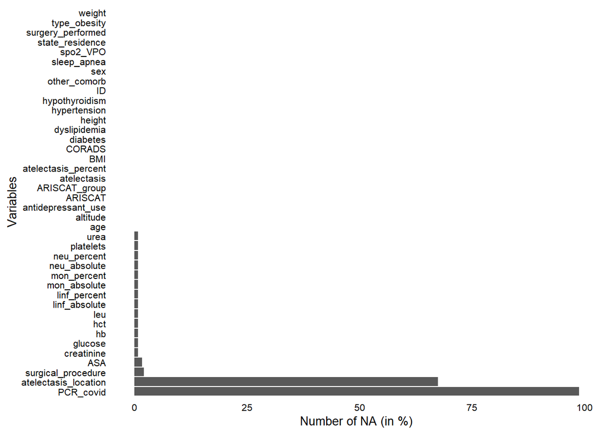

```r
overview_na(data)
```

Missing data for PCR_covid and is explained since only patients who decided to have a test performed on their own will reported the result. The medical center did not require a negative PCR test at that time during the pandemic, reason why PCR tests were not systematically performed. As shown in earlier summary of variables, all available tests (n=3) were negative. This variable will not be analyzed further downstream:

```r
data <- data %>% select(-PCR_covid)
```

The variable atelectasis_location has missing data since those patients who did not have atelectasis naturally do not have a location recorded. Will assess if data are missing for those who had atelectasis:

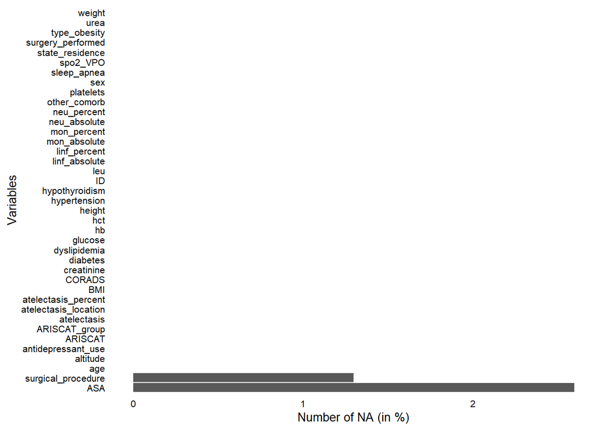

```r
data %>%
  filter(atelectasis == "Yes") %>%
  group_by(atelectasis_location) %>%
  overview_na()
```

There is no missing data for *atelectasis_location* after sub-setting only those who had atelectasis.

Lastly, I will subset all participants without the prior variable to further assess the extent of missing data for other variables:

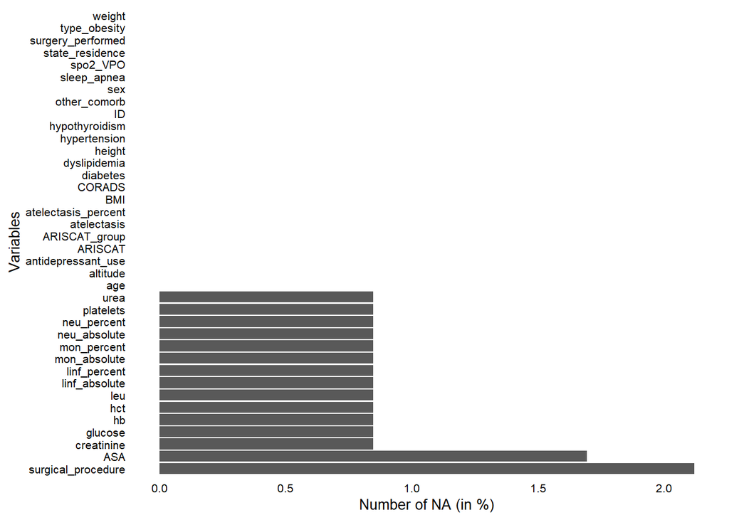

```r
data %>%
  select(-c(atelectasis_location)) %>%
  overview_na()
```

Missing data constitutes **less than 5%** for all remaining variables. Thus, will proceed with **complete-case analysis** without performing any data imputation procedure.